# Master 1 Science des Données, 2020-2021

# Travail pratique de Statistique sur la classification Ascendante Hierarchique avec les arbres hierarchiques.

## Réalisé par : Mulapi Tita Ketsia

# Lab1: Hierarchical clustering

### Dans ce premier TP nous cherchons des clusters hierarchiques

In this lab you will implement hierarchical agglomerative clustering. You will use the scipy.cluster.hierarchy module:

You will generate 2 clusters of random 2D data following gaussian distribution, using the make_blobs function:

The main routine that you want to use is linkage, which actually performs the hierarchical clustering. Linkage takes as input the data matrix, and 2 other arguments. Find out what they're for by reading:

```python
#In this lab you will implement hierarchical agglomerative clustering. You will use the scipy.cluster.hierarchy module:
from scipy.cluster.hierarchy import dendrogram, linkage
```

```python
import scipy
```

```python
#You will generate 2 clusters of random 2D data following gaussian distribution, using the make_blobs function:
from sklearn.datasets import make_blobs
X, label = make_blobs(n_samples=100, centers=2, cluster_std=.5, n_features=4,random_state=0)
```

J'importe la librairie Matplotlib afin de visualiser mon travail

```python
import matplotlib.pyplot as plt
```

Observation des données générées

```python
label
```

```
array([0, 0, 0, 0, 1, 1, 1, 1, 0, 1, 1, 1, 0, 0, 0, 1, 0, 1, 1, 0, 1, 0,
       1, 0, 1, 0, 1, 1, 1, 0, 1, 1, 1, 1, 0, 0, 0, 1, 0, 0, 1, 0, 1, 1,
       0, 0, 1, 1, 0, 0, 1, 0, 1, 0, 0, 1, 1, 0, 1, 1, 0, 1, 1, 1, 0, 1,
       0, 0, 1, 1, 0, 0, 1, 0, 1, 0, 1, 0, 1, 0, 0, 0, 0, 0, 0, 0, 0, 1,
       0, 1, 1, 1, 0, 1, 1, 0, 1, 0, 0, 1])
```

```python
X
```

```
array([[ 1.40468538,  3.97827453,  1.5381461 ,  1.23846092],
       [ 0.63910375,  4.31970261,  1.73734448,  1.23588031],
       [ 0.95662867,  3.71974058,  2.31690585,  0.81189049],
       [ 0.4519936 ,  3.59377836,  1.20213243,  1.87305136],
       [-1.74736533,  2.77770451, -1.43060255,  7.91381194],
       [-0.84463809,  2.57315767, -1.57440257,  7.57486536],
       [-1.82556205,  2.7989214 , -1.96028623,  7.58880007],
       [-2.29730252,  2.94951326, -1.17000251,  7.95155053],
       [ 2.16784247,  4.77602707,  1.59885641,  1.4561718 ],
       [-1.45592743,  2.75821805, -0.9024864 ,  8.18283459],
       [-0.77966174,  1.88288975, -1.03512641,  8.17391403],
       [-1.79833475,  3.12590728, -1.82634699,  8.22605907],
       [ 0.36355232,  4.72596882,  1.55515985,  0.12527811],
       [ 1.2888858 ,  3.5027585 ,  1.50307585,  0.9237462 ],
       [ 1.35678894,  4.36462484,  2.27719914,  1.06450082],
       [-0.99264931,  2.69118936, -1.59217458,  7.22842131],
       [ 1.93774109,  5.04404472,  2.989047  ,  1.35068599],
       [-1.38694171,  2.86880707, -0.79316632,  7.99406912],
       [-1.93358614,  2.1846701 , -0.98772334,  7.54756603],
       [ 0.72086751,  3.71347124,  2.04117641,  1.1118296 ],
       [-1.23764326,  3.09270949, -1.63032774,  7.11656428],
       [ 0.38970838,  5.27559792,  1.84845803,  0.52393625],
       [-1.14027752,  2.32594194, -2.57784189,  8.13861978],
       [ 0.31831637,  4.07299503,  2.02114672,  1.75433502],
       [-1.84562253,  2.71924635, -1.31469606,  7.68656458],
       [ 1.72330962,  4.2012082 ,  2.21180137,  0.47061579],
       [-1.28003312,  2.85983029, -2.26359801,  8.86770645],
       [-2.18016744,  3.7469476 , -1.3073378 ,  7.49537091],
       [-1.70361989,  2.10964517, -1.39417446,  7.45471391],
       [ 1.44989606,  4.22628228,  2.36230721,  1.358767  ],
       [-2.4048493 ,  3.14334949, -1.59026122,  8.66523541],
       [-1.10608838,  2.79315297, -1.22350828,  8.0823784 ],
       [-1.50758874,  2.08952471, -1.74101114,  7.09954251],
       [-1.20524678,  2.13257056, -1.35170761,  8.27554947],
       [ 2.11114739,  3.57660449,  2.07814678,  0.80407173],
       [ 0.23064128,  4.52348318,  2.13860427,  1.21517938],
       [ 1.06498315,  4.10289686,  1.24016835,  1.12905479],
       [-1.17767544,  2.91976771, -0.78233159,  8.00544251],
       [ 0.57456525,  3.95901244,  1.82750127,  0.90640324],
       [ 0.5408715 ,  4.0143625 ,  1.89949126,  0.92574633],
```

[output cut: 45 more lines]

```
       [ 0.39369516,  4.75420057,  2.28809874,  0.12954182],
       [ 1.08040757,  4.79210685,  2.23345072,  1.25095024],
       [-1.53474507,  2.99834635, -1.34358252,  7.63803526],
       [ 1.36216535,  4.7155394 ,  3.1368855 ,  1.56592763],
       [-2.41117324,  3.09562316, -0.84099586,  7.86492281],
       [-1.8897027 ,  2.22620028, -2.03972497,  8.14064971],
       [-2.10558164,  2.76173614, -1.32708928,  8.96382176],
       [ 0.79927312,  3.61631168,  1.73345832, -0.21403792],
       [-1.6823471 ,  2.96658234, -1.0487326 ,  6.44916364],
       [-2.00487651,  2.74489137, -1.48005376,  8.07620075],
       [ 1.74265969,  5.03846671,  2.13274123,  1.08674492],
       [-1.47804153,  3.2093591 , -1.44798029,  8.02048796],
       [ 0.72144399,  4.08475018,  1.42886984,  1.28640884],
       [ 0.62898615,  4.22897006,  1.83769075,  1.82229552],
       [-2.09031692,  2.55254338, -1.44069568,  7.88263581]])
```

# Principe

La méthode de Clustering Hierarchique est une méthode dit agglomérative ou Bottom-UP.

Au départ, chaque point constitue à lui seul un cluster, on va ensuite agglomérer les 2 clusters les plus proches jusqu'à n'obtenir qu'un seul et unique cluster contennat tous les points, cluster que nous allons par la suite visualiser à l'aide d'un arbre appelé **le dendogramme**.

On Obtient la matrice Z qui n'est rien d'autre que :

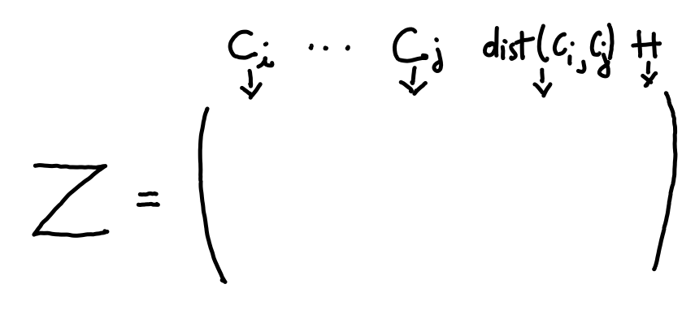

```python
Z = scipy.cluster.hierarchy.linkage(X, method='single', metric='euclidean')
```

Visualisation de Z à l'aide du Dendogramme :

**Le dendogramme, représente les points qui sont agglomérés entre eux, et la longueur de chaque branche de cet arbre, représente la distance entre les points qu'elle relie.**

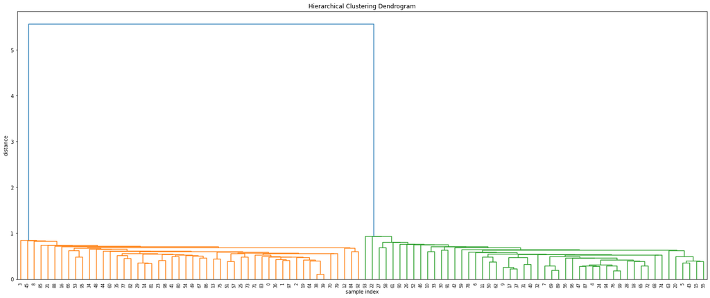

```python
plt.figure(figsize=(25, 10))
plt.title('Hierarchical Clustering Dendrogram')
plt.xlabel('sample index')
plt.ylabel('distance')
dendrogram(Z,leaf_rotation=90., # rotates the x axis labels
 leaf_font_size=8., # font size for the x axis labels
)
plt.show()
```

Dans un dendogramme, il est possible de trouver un nombre de cluster en décidant du niveau à partir du quel on veut le couper.

Les différentes mesures permettant de définir des clusters sont appelés des liens et il en existe 3 :

- Single Linkage (Lien Simple) : C'est l'écart ou la distance minimale
- Average Linkage (Lien Moyen) : C'ets l'écart ou la distance moyenne
- Complete Linkage (Lien complet) : C'est l'écart ou la distance maximale

ici on se décide d'afficher notre dendogramme en mode tronqué :

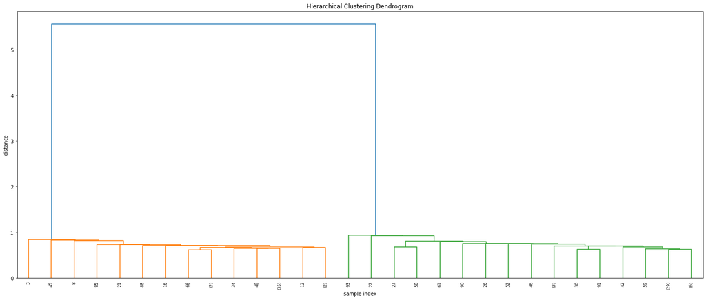

```python
plt.figure(figsize=(25, 10))
plt.title('Hierarchical Clustering Dendrogram')
plt.xlabel('sample index')
plt.ylabel('distance')
dendrogram(Z,leaf_rotation=90., # rotates the x axis labels
 leaf_font_size=8., # font size for the x axis labels
truncate_mode='lastp')
plt.show()
```

On oriente notre dendogramme vers la droite et, on l'affiche en mode tronqué aussi :

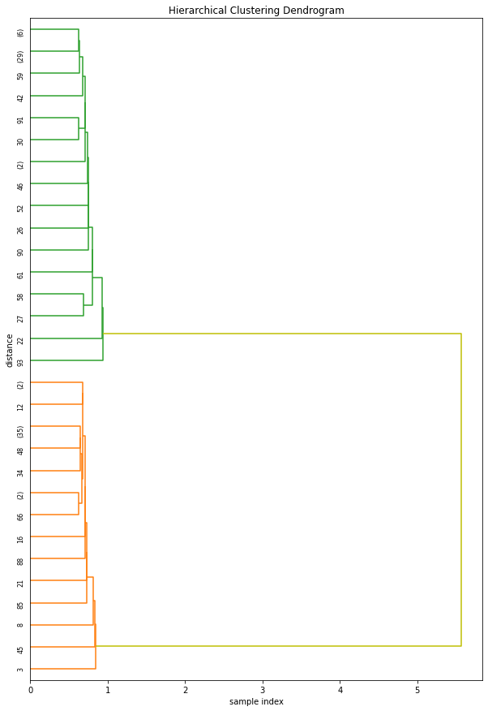

```python
plt.figure(figsize=(10, 15))
plt.title('Hierarchical Clustering Dendrogram')
plt.xlabel('sample index')
plt.ylabel('distance')
dendrogram(Z,above_threshold_color='y',leaf_rotation=90., # rotates the x axis labels
 leaf_font_size=8.,
           orientation='right',# font size for the x axis labels
truncate_mode='lastp')
plt.show()
```

ici, on affche les clusters suivant un ordre ascendant :

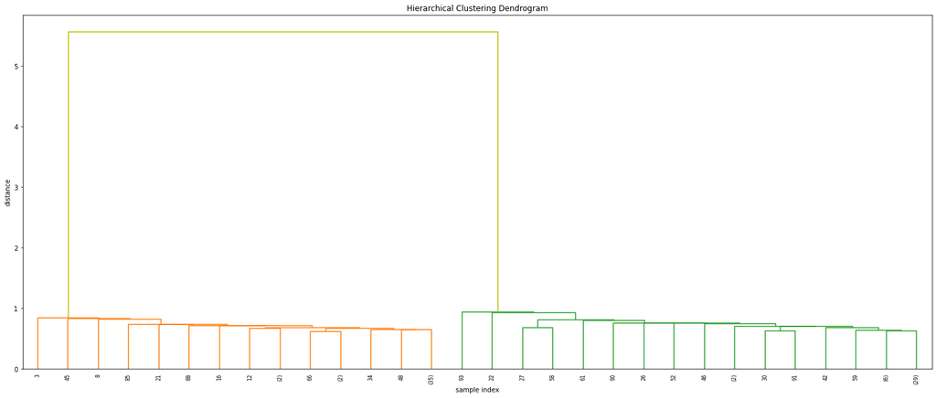

```python
plt.figure(figsize=(25, 10))
plt.title('Hierarchical Clustering Dendrogram')
plt.xlabel('sample index')
plt.ylabel('distance')
dendrogram(Z,above_threshold_color='y',leaf_rotation=90., # rotates the x axis labels
 leaf_font_size=8.,
           orientation='top',# font size for the x axis labels
truncate_mode='lastp',count_sort='ascending')
plt.show()
```

On affiche les clusters suivnt un ordre descendant :

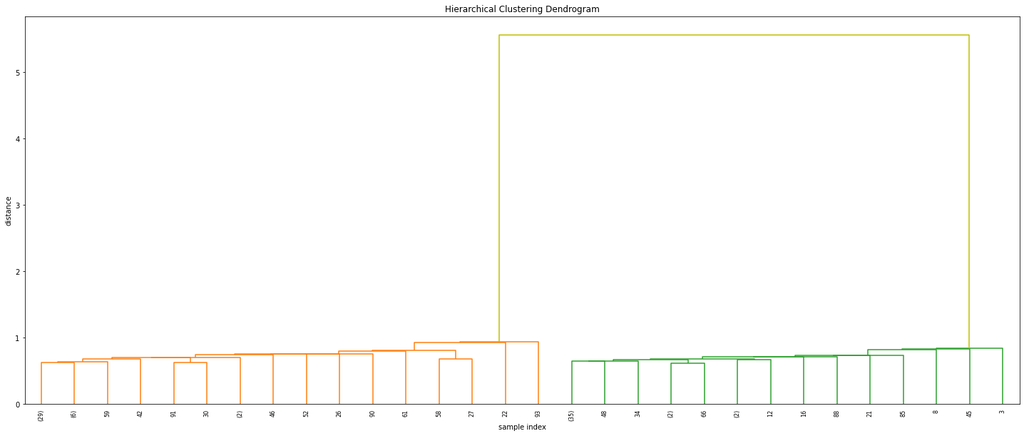

```python
plt.figure(figsize=(25, 10))
plt.title('Hierarchical Clustering Dendrogram')
plt.xlabel('sample index')
plt.ylabel('distance')
dendrogram(Z,above_threshold_color='y',leaf_rotation=90., # rotates the x axis labels
 leaf_font_size=8.,
           orientation='top',# font size for the x axis labels
truncate_mode='lastp',count_sort='descending')
plt.show()
```

Then you'll notice 2 different ways to get the clusters: either you specify the number of clusters, or you specify the maximum distance between clusters. You can then compare the clusters and the label variables.

```python
from scipy.cluster.hierarchy import fcluster
```

**On commence d'abord par observer ce qui se passe lorsqu'on forme des amas plats de sorte que les observations originales dans chaque amas plat n'aient pas une distance cophénétique supérieure à max_d :**

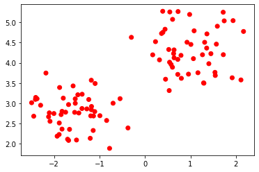

```python
max_d = 50
clusters = fcluster(Z, max_d, criterion='distance')
plt.scatter(X[:,0], X[:,1], c=clusters, cmap='prism')
plt.show()
```

On voit alors que le seuil max_d=50 est suffisamment grand pour permettre la fusion de tous les points de données, de sorte qu'un seul cluster soit renvoyé.

**On maintenant va trouve un seuil minimum pour que la distance cophénétique entre deux observations d'origine dans le même amas plat ne soit pas dépassé et que, pas plus de t amas plats soient formés :**

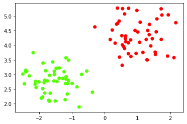

```python
clusters = fcluster(Z, t=2, criterion='maxclust')
plt.scatter(X[:,0], X[:,1], c=clusters, cmap='prism')
plt.show()
```

# Conclusion :

### Certe complexe, le clustering hierarchique est cependant en mon sens, flexible car on peut décider sur le choix de la distance, le nombre de clusters, et prouver à l'aide de l'inertie, qu'il est possible d'avoir des clusters, il sera alors dans ce cas question de constituer des clusters en veillant à ce que l'inertie intra-classe soit la plus faible possible et, que l'inertie inter-classe présente la variance la plus élevés.

# Travail pratique de statsitsiques numéro 2 :

# Technique d'apprentissage non supervisées K-moyennes (K-means)

# Table des matières

1. **AVANT PROPOS**
   1. Quid K-means
   2. Les termes
   3. Importations et phase de data-preprocessing
2. **K-mean from scratch**
   1. Création des fonctions demandées
   2. Test de nos fonctions avec data1.txt
   3. Test de nos fonctions avec les autres datasets
3. **Application des K-means avec Sklearn sur les 3 datasets**
4. **Comparaion & conclusion**

# 1. Avant-propos

## A. Qu'en est-il des K-means ?

Depuis l'année denrière, nous avons vu que la pluspart des applications de machine learning s'appuie sur des techniques d'apprentissage supervisé, et pourtant, ce n'est pas dans tous les cas que l'on retrouvera des jeux de données labéllisés.

Selon **Yann LeCun** : << Si l'I.A. était un gâteau, l'apprentissage non supervisé serait LE GATEAU, l'apprentissage supervisé serait la glace et, l'apprentissage par renforcmeent serait la serise sur le gâteau >>. intérressant n'est-ce pas ? mais que cela signifie ?

Dans ce cours de Statistqiues du master 1, on s'intérresse à des méthodes d'apprentissages non supervisé ayant pour tâches : La réduction des dimensions(tel que réalisé dans le TP3 sur les ACP), la détéction des anomalies (intérressant dans le secteur industriels, le secteur des banques et tout ce qui touche à la sécurité), l'etimation de la densité(utilisé dans la tâche précédente, celle-ci est un dispensable our une meilleure visualisation des données) et, le partitionnement (pour le regroupement des observations similaires en clusters) c'est l'objet de ce TP, qui nous emmène à utiliser un des algorithmes les plus populaires en la matière : K-moyennes.

Conçu en 1957 dans le laboratoires Bell par Stuart P. Lloyd et publié en 1982, l'algorithme des K-moyennes se dénomme aussi algorithme de Lloyd-Forgy.

**Le principe est simple :** On commence par choisir K centroïdes en raisons de K clusters qu'on aimerait avoir ensuite, au fur et à mesure qu'on déroulera l'algorithme, dans sa partie itérative, on affecte, chauqe observations du jeu de données au cluster dont le centroïde est le plus proches. Pour chosir les nouveaux cnetroïdes au fil des itérations, on calcule la moyenne des observations de chaque cluster et, on continue iansi jusqu'à ce que les centroïdes de tous les obsevrations restent inchangés (ne bouge plus). L'algorithme ne tournera donc pas indéfinimeent, on dit aussi qu'il lui faut en fonction de la distribution des données très peu d'itération en générale, pour converger.

## B. Les termes

> Centroïde : C'est l'inertie ou le centre de gravité ou encore, la dispersion au centre de gravité

> Similarité : Ce critère varie en fonction d'un domaine, dans notre cas, on se contentera de la distance euclidienne car elle vérifie trois propriétés qui sont l'auto-similarité, la symétrie et, l'inégalité triangulaire car plus 2 points sont éloignés et moins ils sont similaires. Dans un autre contexte on aurait utilisé le coefficient de Pearson qui n'est rien d'autre que le coefficient de correlation, etc.

> Cluster : Un regroupement de données homogènes ou dont la distance entre la donnée et le centre du cluster est petite. Les clusters doivent être ressérés sur eux mêmes (Inertie intra-classes), loin les uns des autres (inertie inter-classes), tout l'enjeux de cette méthode réside donc dans la discrimination ou, la segmentation des données.

## C. Importation des librairies et phase d'exploration des données

```python
import numpy as np
import pandas as pd
import matplotlib.pyplot as plt
import random
```

```python
def open_dataset(path):
    X = np.loadtxt(path)
    plt.scatter(X[:,0], X[:,1])
    plt.grid(True)
    plt.show()
    return pd.DataFrame({"X1":X[:,0],"X2":X[:,1]})
```

```python
X = np.loadtxt("data1.txt")
print(X)
```

```
[[-6.315382  6.344938]
 [-4.943573  7.821684]
 [-8.920876  2.705258]
 ...
 [ 0.645414  0.058871]
 [ 0.679295 -1.39178 ]
 [ 0.998671  1.712854]]
```

```python
print(X.shape)
```

```
(1000, 2)
```

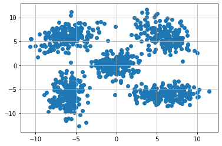

```python
plt.scatter(X[:,0], X[:,1])
plt.grid(True)
plt.show()
```

```python
data = pd.DataFrame({"X1":X[:,0],"X2":X[:,1]})
```

```python
data
```

|  | X1 | X2 |
| --- | --- | --- |
| 0 | -6.315382 | 6.344938 |
| 1 | -4.943573 | 7.821684 |
| 2 | -8.920876 | 2.705258 |
| 3 | -5.661533 | 7.425065 |
| 4 | -5.918269 | 5.697313 |
| ... | ... | ... |
| 995 | -0.532394 | -0.478236 |
| 996 | -0.596780 | -1.310213 |
| 997 | 0.645414 | 0.058871 |
| 998 | 0.679295 | -1.391780 |
| 999 | 0.998671 | 1.712854 |

1000 rows × 2 columns

```python
len(data)
```

```
1000
```

# 2. K-means from scratch

1) Implement the k-means algorithm from scratch. K-means work as follows:

Step 1 - Pick K random points as cluster centers called centroids.

## A. Création des fonctions demandées

## Choix des K centroïdes

```python
############
#
#Cette focntion renvoie une liste de K centroides selon K-cluster
#
###########
def pick_init(k, data):
    #choix d'un point au hasard dans le dataframe de départ (data)
    point = data.sample()
    #construction du dataframe des centroides
    centroide = pd.DataFrame({"indexes":point.index[0],"X1":point.iloc[:,0],"X2":point.iloc[:,1]})
    #pour i allant de 0 à k-1, on randomize tant que le nouveau point
    #correspond à un point déjà existant dans le df des centroides
    #sinon, on ajoute ce nouveau point dans le df centroides
    for i in range(k-1):
        point = data.sample()
        while(centroide.indexes.any()==point.index[0]):
            point = data.sample()
        centroide.loc[i,"indexes"]=point.index[0]
        centroide.loc[i,"X1"]=point.iloc[0,0]
        centroide.loc[i,"X2"]=point.iloc[0,1]
    #je décide que mes nouveaux indexes ne sont plus auto-incrémenté mais
    #représente la position du point dans le datasets (index du point dans le data set)
    picked = centroide.set_index("indexes")
    #on convertie en int (0) nos indexes qui sont en float (0.0)
    picked.index = picked.index.astype("int")
    return picked
```

```python
df = pick_init(5, data)
```

```python
df
```

| indexes | X1 | X2 |
| --- | --- | --- |
| 108 | 3.837317 | 7.426355 |
| 814 | -5.671770 | -6.644149 |
| 277 | 8.327795 | -5.033136 |
| 300 | -5.824326 | -8.025893 |
| 800 | -6.861823 | -7.105626 |

Les 5 centroïdes pris aléatoirement.

## Ici on visualise les K centroides choisis aléatoirement

```python
############
#
#Ici on visualize les données, avec leur dentroïde de départ
#(cette méthode ne se répète pas, la second je l'utilise pour le clustering intégral)
#Elle nous permet de savoir quels sont els centroides de départ car plus loin, nous ne détaillerons pas
#les différents clusteurs au fur et à mesur des itérations
#
###########
def kmean_visualization_centroides(k, data):
    for i in range(len(data)):
        if(i not in k.index.tolist()):
            plt.scatter(data.iloc[i,0], data.iloc[i,1],color="black", label="Points")
    for i in range(len(data)):
        if(i in k.index.tolist()):
            plt.scatter(data.iloc[i,0], data.iloc[i,1],color="blue", label="Centroïdes")
plt.show()
```

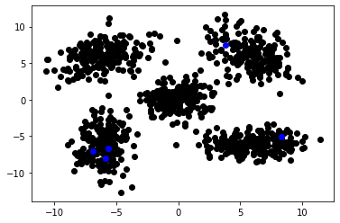

```python
kmean_visualization_centroides(df, data)
```

## Ici j'écris les algo qui me permettront de générer des couleurs en focntion d'un nombre de k cluster, pour chaque centroides aussi afin de mieux visualiser les résultats

```python
#############
#
#Je crée un vecteur de couleur, dont la taille (nombre de couleur)
#est fonction du nombre de cluster
#
############
def couleur_generation(k):
    couleurs=[] #le vecteur qui contiendra les couleurs qui seront focntion du nombre K
    code_couleur_hexadecimal = ["0","1","2","3","4","5","6","7","8","9","a","b","c","d","e","f"]
    hex_ = 0
    hex1 = 0
    hex2 = 0
    hex3 = 0
    hex4 = 0
    hex5 = 0
    hex6 = 0
    taille_alphabet = len(code_couleur_hexadecimal) #16
    for i in range(k):
        hex1 = code_couleur_hexadecimal[np.random.randint(taille_alphabet)]
        hex2 = code_couleur_hexadecimal[np.random.randint(taille_alphabet)]
        hex3 = code_couleur_hexadecimal[np.random.randint(taille_alphabet)]
        hex4 = code_couleur_hexadecimal[np.random.randint(taille_alphabet)]
        hex5 = code_couleur_hexadecimal[np.random.randint(taille_alphabet)]
        hex6 = code_couleur_hexadecimal[np.random.randint(taille_alphabet)]
        hex_ = "#"+hex1+hex2+hex3+hex4+hex5+hex6
        #On veut que nos couleurs soient différentes du blanc et du noir
        #si nos couleurs sont blanc ou noir, on change un R, un V et un B
        while(hex_=="#000000" or hex_=="#ffffff"):
            hex6 = code_couleur_hexadecimal[np.random.randint(17)]
            hex4 = code_couleur_hexadecimal[np.random.randint(17)]
            hex1 = code_couleur_hexadecimal[np.random.randint(17)]
            hex_ = "#"+hex1+hex2+hex3+hex4+hex5+hex6
        couleurs.append(hex_)
    return couleurs
```

```python
#############
#
#Coloriation intégrale (cluster + centroide)
#
############
def kmean_visualization_cluster(clusters, K, centroides):
    Cluster_couleurs = couleur_generation(K) #les couleurs générées pour les clusters
    Centroides_couleurs = couleur_generation(K) #les couleurs générées pour les centroides
    clust = []
    #On prépare nos clusters
    for i in range(K):
        clust.append([list(clusters['X1'][clusters['Cluster'] == i]), list(clusters['X2'][clusters['Cluster'] == i])])
    fig,ax = plt.subplots()
    i=0
    #On colorie nos Clusters
    for color in Cluster_couleurs:
        ax.scatter(clust[i][0], clust[i][1], c=color,alpha=0.4)
        i = i+1
    #On colorie nos Centroides : Facultatif
    for i in range(K):
        ax.scatter(centroides[i][0], centroides[i][1], c=Centroides_couleurs[i], marker = "o")
        ax.legend()
    plt.show()
```

## Ci-dessous j'écris les algorithmes de traitement :

Step 2 - Assign each point to nearest cluster by calculating its distance to each centroid.

> Une distance euclidienne

Step 3 - Find new cluster center by taking the average of the assigned points.

Step 4 - Repeat Step 2 and 3 until the desired number of iterations is reached or until the centroid positions do not evolve anymore.

> Clusteriser : ici on effectue "Des clusterizations" en fonction du nombre d'itération

```python
#############
#
#Calcul de la distance euclidienne entre les points et les centroides
#
############
def distance_eucl_integrale(dataX1, dataX2,centroideX1,centroideX2):
    return ((dataX1-centroideX1)**2+(dataX2-centroideX2)**2)**0.5
```

```python
#Une clusterization est une attribution d'un point à un cluster, ici on le fait pour tous
#les points d'un jeux de données
def a_clusterization(K, data):
    clusters = [] #ici je stock chaque point avec son cluster
    for i in range(len(data)):
        df_distances = pd.DataFrame()
        dist = [] #ici je stock les distance entre un point et les centroides
        for l in range(0,len(K)):
            distance = distance_eucl_integrale(data.iloc[i,0],data.iloc[i,1],K.X1.iloc[l],K.X2.iloc[l])
            tuple_ = (distance,l)
            dist.append(tuple_) #on conserve la distance et le cluster
        cluster_by_dist_minimum = min(dist) #au final, je ne consèrve que la distance min
        clusters.append((*data.iloc[i],cluster_by_dist_minimum[1])) #un vecteur de points reparti selon chaque cluster(centroide)
    return pd.DataFrame(clusters, columns=["X1", "X2", "Cluster"])
```

```python
#############
#
#Ici mon clustering évolue, il fait appel à la création d'un clutering
#
############
def Clusteriser(initCentroide, data, iterations):
    #je recommence mon claclul de cluster
    centroides_update =  a_clusterization(initCentroide,data)
    #j'initialise les centroides de départ
    centroides_suivant = initCentroide
    #vecteur de sauvegarde des cluster suivant (itérations) jusqu'aux finaux
    clustering_final = []
    #je fais autant d'itérations
    for j in range(iterations):
        #à chaque itération et, pour chaque centroides de départ ou suivant
        for i in range(len(initCentroide)):
            #je récupères tous els pointys d'un même cluster
            cluster_update = centroides_update[centroides_update['Cluster'] == i]
            #je moyennes les X1 et les X2 pour déterminer les centroides suivants
            centroides_suivant.iloc[i] = np.array([np.mean(cluster_update.loc[:,"X1"]), np.mean(cluster_update.loc[:,"X2"])])
        #je mets à jours mes clusters en fonctions des nouveaux centroides
        centroides_update = a_clusterization(centroides_suivant, data)
    ##
    #ICI JE PEUX FAIRE EN SORTE QU'ON VOIT A CHAQUE ITERATION COMMENT LES DONNEES SONT DISCRIMINES LORSQUE LE NOMBRE
    #D'ITERATION PEUT ETRE IMPORTANT MASI POUR DES RAISONS DE TEMPS, JE N'IRAI PAS JUSQU'A CE POINT LA.
    ##
    #je construit mes clusters finaux en fonctionsd des derniers clusters construit(updaté)
    for i in range(len(centroides_suivant)):
        clustering_final.append(centroides_suivant.iloc[i])
    return centroides_update, clustering_final
```

### Ici on test notre méthode qui trouve les clusters finaux au bout des j iterations

```python
initCentroide = pick_init(4, data)
iterations = 10
new_clusters, new_center = Clusteriser(initCentroide, data, iterations)
```

```python
new_clusters
```

|  | X1 | X2 | Cluster |
| --- | --- | --- | --- |
| 0 | -6.315382 | 6.344938 | 1 |
| 1 | -4.943573 | 7.821684 | 1 |
| 2 | -8.920876 | 2.705258 | 1 |
| 3 | -5.661533 | 7.425065 | 1 |
| 4 | -5.918269 | 5.697313 | 1 |
| ... | ... | ... | ... |
| 995 | -0.532394 | -0.478236 | 1 |
| 996 | -0.596780 | -1.310213 | 1 |
| 997 | 0.645414 | 0.058871 | 1 |
| 998 | 0.679295 | -1.391780 | 1 |
| 999 | 0.998671 | 1.712854 | 1 |

1000 rows × 3 columns

## B. Test de nos fonctions avec data1.txt

# Ici je construis ma méthode Kmean (Kmoyen) : je fais appelle à toutes les éthodes necessaires

```python
def kMoyen(k,data,iterations):
    initCentroide = pick_init(k, data) #je récupère au hasard les centroides
    kmean_visualization_centroides(initCentroide, data) #je visualise les centroides
    clusters, centroides = Clusteriser(initCentroide, data, iterations) #je clusterise
    print("")
    print("clustering final")
    print(clusters)
    print("")
    print("centroides finaux")
    print(centroides)
    print("")
    #clusters en couleur
    kmean_visualization_cluster(clusters, k, centroides)
```

# Ici je teste mon algorithme

You will test your algorithm on the data files data1.txt, data2.txt, data3.txt. Use the code below to load and display the data. NB: remove the 's' character at the end of the data1.txt file!

3) Run the code with different starting points and compare the output.

Cas 1 : un nombre de cluster petit et un nombre d'itération grand

```
No handles with labels found to put in legend.
No handles with labels found to put in legend.
```

```
clustering final
           X1        X2  Cluster
0   -6.315382  6.344938        0
1   -4.943573  7.821684        0
2   -8.920876  2.705258        0
3   -5.661533  7.425065        0
4   -5.918269  5.697313        0
..        ...       ...      ...
995 -0.532394 -0.478236        1
996 -0.596780 -1.310213        1
997  0.645414  0.058871        0
998  0.679295 -1.391780        1
999  0.998671  1.712854        0

[1000 rows x 3 columns]

centroides finaux
[X1   -0.087584
X2    5.097040
Name: 149, dtype: float64, X1   -0.077327
X2   -5.141070
Name: 427, dtype: float64]
```

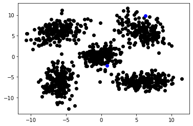

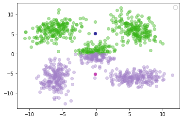

```python
kMoyen(2,data,100)
```

Cas 2 : un nombre de cluster petit et un nombre d'itération petit

```
No handles with labels found to put in legend.
No handles with labels found to put in legend.
```

```
clustering final
           X1        X2  Cluster
0   -6.315382  6.344938        0
1   -4.943573  7.821684        0
2   -8.920876  2.705258        0
3   -5.661533  7.425065        0
4   -5.918269  5.697313        0
..        ...       ...      ...
995 -0.532394 -0.478236        0
996 -0.596780 -1.310213        0
997  0.645414  0.058871        1
998  0.679295 -1.391780        1
999  0.998671  1.712854        1

[1000 rows x 3 columns]

centroides finaux
[X1   -5.198491
X2   -0.110017
Name: 584, dtype: float64, X1    4.813280
X2    0.102268
Name: 667, dtype: float64]
```

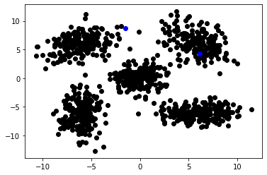

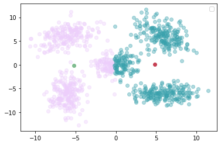

```python
kMoyen(2,data,5)
```

Cas 3 : un nombre de cluster convenable au regard de la dispersion des points et un nombre d'itération petit

```
No handles with labels found to put in legend.
No handles with labels found to put in legend.
No handles with labels found to put in legend.
No handles with labels found to put in legend.
No handles with labels found to put in legend.
```

```
clustering final
           X1        X2  Cluster
0   -6.315382  6.344938        3
1   -4.943573  7.821684        3
2   -8.920876  2.705258        3
3   -5.661533  7.425065        3
4   -5.918269  5.697313        3
..        ...       ...      ...
995 -0.532394 -0.478236        4
996 -0.596780 -1.310213        4
997  0.645414  0.058871        4
998  0.679295 -1.391780        4
999  0.998671  1.712854        4

[1000 rows x 3 columns]

centroides finaux
[X1   -6.000920
X2   -8.333437
Name: 823, dtype: float64, X1   -5.936216
X2   -4.906843
Name: 806, dtype: float64, X1    5.904213
X2   -4.870344
Name: 725, dtype: float64, X1   -6.531196
X2    5.541673
Name: 392, dtype: float64, X1    2.233595
X2    3.653545
Name: 437, dtype: float64]
```

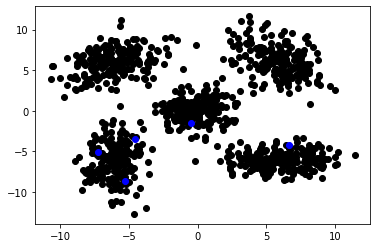

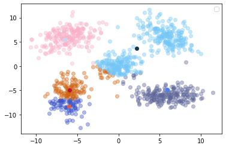

```python
kMoyen(5,data,2)
```

Cas 4 : un nombre de cluster convenable au regard de la dispersion des points et un nombre d'itération très grand afin de mieux segmenter ou discriminer les données (points) entre elles.

```
No handles with labels found to put in legend.
No handles with labels found to put in legend.
No handles with labels found to put in legend.
No handles with labels found to put in legend.
No handles with labels found to put in legend.
```

```
clustering final
           X1        X2  Cluster
0   -6.315382  6.344938        1
1   -4.943573  7.821684        3
2   -8.920876  2.705258        1
3   -5.661533  7.425065        3
4   -5.918269  5.697313        1
..        ...       ...      ...
995 -0.532394 -0.478236        4
996 -0.596780 -1.310213        4
997  0.645414  0.058871        4
998  0.679295 -1.391780        4
999  0.998671  1.712854        0

[1000 rows x 3 columns]

centroides finaux
[X1    5.171159
X2    5.494586
Name: 631, dtype: float64, X1   -7.479371
X2    5.297864
Name: 563, dtype: float64, X1    5.789613
X2   -5.829811
Name: 717, dtype: float64, X1   -4.406253
X2    6.635883
Name: 580, dtype: float64, X1   -3.712091
X2   -3.728706
Name: 444, dtype: float64]
```

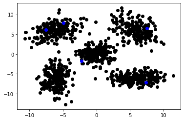

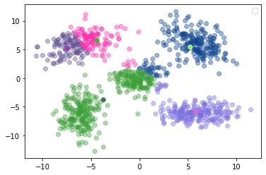

```python
kMoyen(5,data,200)
```

Cas 5 : un nombre de cluster grand et un nombre d'itération petit

[output not shown]

```
clustering final
           X1        X2  Cluster
0   -6.315382  6.344938        3
1   -4.943573  7.821684        1
2   -8.920876  2.705258        3
3   -5.661533  7.425065        3
4   -5.918269  5.697313        3
..        ...       ...      ...
995 -0.532394 -0.478236        0
996 -0.596780 -1.310213        0
997  0.645414  0.058871        0
998  0.679295 -1.391780        0
999  0.998671  1.712854        0

[1000 rows x 3 columns]

centroides finaux
[X1   -0.072478
X2    0.008444
Name: 757, dtype: float64, X1   -3.105261
X2    8.000078
Name: 80, dtype: float64, X1    6.953276
X2   -7.039505
Name: 276, dtype: float64, X1   -6.480079
X2    5.802648
Name: 56, dtype: float64, X1   -5.902761
X2   -4.111215
Name: 317, dtype: float64, X1    8.571613
X2   -5.835125
Name: 221, dtype: float64, X1    4.15472
X2   -6.16094
Name: 796, dtype: float64, X1    6.899343
X2   -4.409269
Name: 280, dtype: float64, X1   -6.210078
X2   -7.757934
Name: 313, dtype: float64, X1    5.840384
X2    6.171398
Name: 666, dtype: float64]
```

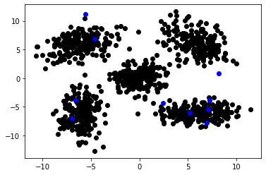

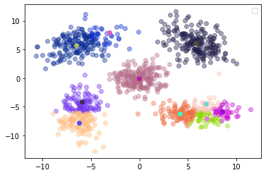

```python
kMoyen(10,data,3)
```

Cas 6 : un nombre de cluster grand et un nombre d'itération grand

[output not shown]

```
clustering final
           X1        X2  Cluster
0   -6.315382  6.344938        1
1   -4.943573  7.821684        1
2   -8.920876  2.705258        1
3   -5.661533  7.425065        1
4   -5.918269  5.697313        1
..        ...       ...      ...
995 -0.532394 -0.478236        2
996 -0.596780 -1.310213        2
997  0.645414  0.058871        0
998  0.679295 -1.391780        2
999  0.998671  1.712854        0

[1000 rows x 3 columns]

centroides finaux
[X1   -0.095012
X2    1.067614
Name: 405, dtype: float64, X1   -6.121457
X2    6.074521
Name: 583, dtype: float64, X1   -0.016886
X2   -1.273154
Name: 423, dtype: float64, X1   -5.938683
X2   -4.255265
Name: 336, dtype: float64, X1   NaN
X2   NaN
Name: 583, dtype: float64, X1    7.299620
X2    4.762986
Name: 645, dtype: float64, X1   -6.201077
X2   -7.904057
Name: 328, dtype: float64, X1    5.107326
X2    5.879510
Name: 640, dtype: float64, X1    4.643926
X2    8.684420
Name: 653, dtype: float64, X1    6.011466
X2   -6.066617
Name: 994, dtype: float64]
```

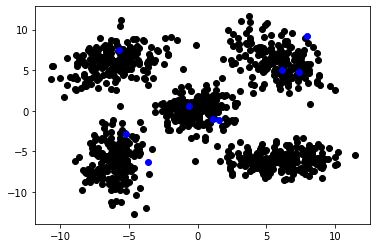

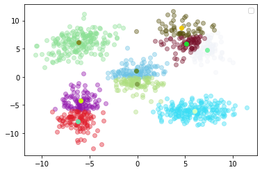

```python
kMoyen(10,data,150)
```

## C. Test de nos fonctions avec les autres datasets

## On test l'algo avec les autres dataset

### Dataset 2 :

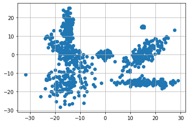

```python
data2 = open_dataset("data2.txt")
```

```
No handles with labels found to put in legend.
No handles with labels found to put in legend.
No handles with labels found to put in legend.
No handles with labels found to put in legend.
No handles with labels found to put in legend.
```

```
clustering final
            X1        X2  Cluster
0    -0.878755  0.486313        4
1    -0.221894 -0.109937        4
2    -1.005302 -1.402324        4
3    -0.141265  1.894775        4
4    -1.061511 -1.284591        4
..         ...       ...      ...
995 -15.768583 -1.289119        1
996  -8.972010 -1.439961        4
997 -17.843235  0.551403        3
998  -9.824211 -4.338468        1
999 -13.503873  1.238530        3

[1000 rows x 3 columns]

centroides finaux
[X1    15.973177
X2    11.328702
Name: 675, dtype: float64, X1   -14.829089
X2   -12.624334
Name: 972, dtype: float64, X1    14.916829
X2   -11.689584
Name: 125, dtype: float64, X1   -15.818570
X2    10.608821
Name: 209, dtype: float64, X1   -0.511285
X2   -0.316089
Name: 142, dtype: float64]
```

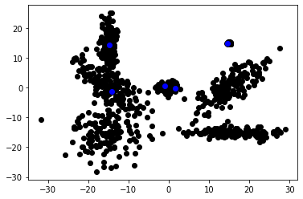

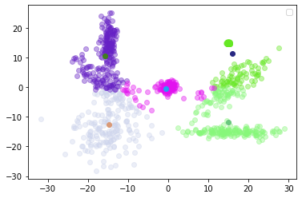

```python
kMoyen(5,data2,10)
```

```
No handles with labels found to put in legend.
No handles with labels found to put in legend.
No handles with labels found to put in legend.
No handles with labels found to put in legend.
No handles with labels found to put in legend.
```

```
clustering final
            X1        X2  Cluster
0    -0.878755  0.486313        1
1    -0.221894 -0.109937        1
2    -1.005302 -1.402324        1
3    -0.141265  1.894775        1
4    -1.061511 -1.284591        1
..         ...       ...      ...
995 -15.768583 -1.289119        3
996  -8.972010 -1.439961        1
997 -17.843235  0.551403        4
998  -9.824211 -4.338468        3
999 -13.503873  1.238530        4

[1000 rows x 3 columns]

centroides finaux
[X1    15.973177
X2    11.328702
Name: 35, dtype: float64, X1   -0.511285
X2   -0.316089
Name: 482, dtype: float64, X1    14.916829
X2   -11.689584
Name: 475, dtype: float64, X1   -14.829089
X2   -12.624334
Name: 426, dtype: float64, X1   -15.818570
X2    10.608821
Name: 208, dtype: float64]
```

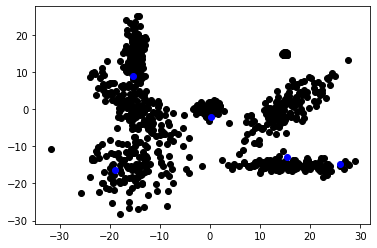

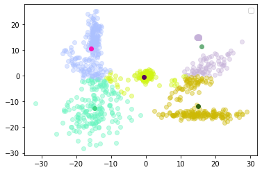

```python
kMoyen(5,data2,50)
```

```
No handles with labels found to put in legend.
No handles with labels found to put in legend.
No handles with labels found to put in legend.
```

```
clustering final
            X1        X2  Cluster
0    -0.878755  0.486313        1
1    -0.221894 -0.109937        1
2    -1.005302 -1.402324        1
3    -0.141265  1.894775        1
4    -1.061511 -1.284591        1
..         ...       ...      ...
995 -15.768583 -1.289119        0
996  -8.972010 -1.439961        0
997 -17.843235  0.551403        0
998  -9.824211 -4.338468        0
999 -13.503873  1.238530        0

[1000 rows x 3 columns]

centroides finaux
[X1   -15.15886
X2    -6.61961
Name: 383, dtype: float64, X1    0.790162
X2    9.976242
Name: 948, dtype: float64, X1    15.468102
X2    -7.425937
Name: 399, dtype: float64]
```

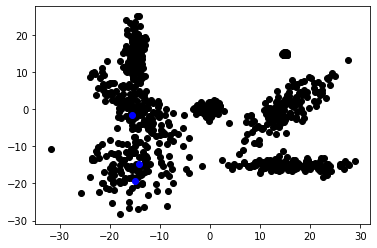

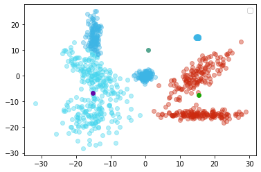

```python
kMoyen(3,data2,50)
```